# Working woth limited dependent variables

Nic Rivers

10/30/2019

## Introduction

In some cases, we will encounter research questions in which the dependent variable ($Y$) is categorical, not continuous. For example, if we were asking whether a spouse’s income affects an individual’s formal labour force participation, the dependent variable (labour force participation) is categorical (yes - participate in the labour market, or no - do not participate). Or we might be asking about whether the ownership of natural resources ($X$) leads to conflict in a country ($Y$), where conflict is either present or absent. These situations are an extension from our initial introduction to the regression model, in which we have treated $Y$ as continuous.

What might happen if we apply our standard methods in this case? Let’s try it using a data set on health and income from the General Social Survey (2016). We will create a dummy variable called `badhealth` which is equal to one if the respondent reports having poor or only fair health; otherwise it takes on a value of zero. Our independent variable in this exercise will be income. Income is of course a numeric variable, but in this survey (and many others) it is recoded as a categorical variable; here taking on values from 1 (low income) to 6 (high income). Although this is a categorical variable, for illustrative purposes, we will treat it here as a numeric variable. The following code generates the data that we will use for this exercise, and provides a glimpse of what it looks like.

```r
library(tidyverse)
library(huxtable)

dat <- read_csv("../class_2/gss-12M0030X-E-2016-c-30/gss-12M0030X-E-2016-c-30_F1.csv") %>%
  select(income=TTLINCG2, SRH_110)

dat$badhealth <- as.numeric(dat$SRH_110 == 4 | dat$SRH_110 == 5)
dat$badhealth[dat$SRH_110 >=6] <- NA

dat <- dat %>%
  filter(!is.na(badhealth)) %>%
  select(income, badhealth)

head(dat)
```

| income | badhealth |
| --- | --- |
| 2 | 0 |
| 4 | 0 |
| 2 | 0 |
| 1 | 1 |
| 1 | 0 |
| 5 | 0 |

When we estimate a regression of `badhealth` on `income` using our standard approach, we get the following results:

```r
m1 <- lm(badhealth ~ income, data=dat)
huxreg(m1)
```

|  | (1) |
| --- | --- |
| (Intercept) | 0.223 *** |
|  | (0.005) |
| income | -0.031 *** |
|  | (0.002) |
| N | 19538 |
| R2 | 0.014 |
| logLik | -7433.947 |
| AIC | 14873.894 |
| *** p < 0.001; ** p < 0.01; * p < 0.05. |  |

Let’s try to interpret the `income` (slope) coefficient the way we normally do. This coefficient says that a one-unit increase in income (on the 1-6 scale we are using) is associated with a -0.031 reduction in `badhealth`. How can this be? The dependent variable `badhealth` can only take on values of 0 or 1 – it’s a dummy variable! So how can it be meaningful to reduce badhealth by 0.031? Despite the seeming inconsistency here, this regression is still meaningful. It is showing us the *average* change in `badhealth` for a one-unit increase in income: you can think of this as the *probability* of someone reporting that they experience bad health changing as income changes. In this case the probability of someone reporting bad health falls by 3.1% when income increases by one unit. Thus the model we have just esimated is typically referred to as a linear probability model (LPM). Other statistics (t-stats, standard errors, R2, etc.) that are reported are interpreted in exactly the same way as with any other regression.

LPMs are easy to execute and interpret, and for this reason, they are often recommended as a suitable approach for dealing with cases where $Y$ is discrete. However, they do have one additional potential drawback that bears emphasizing: they are linear (as the name suggests). This means that in our case, a one-unit change in income is predicted to have the same effect on health, regardless of whether the individual is at low income or at high income. Moreover, this means that in some cases, when we try to generate predictions using our LPM, we will end up with meaningless results. For example, imagine that our income scale went from 1-8, rather than 1-6. In this case, when we tried to predict the probability of someone reporting bad health with an income of 8, we would obtain: $\beta_0 + \beta_1 \times \text{income} = 0.22 - 0.31 \times 8 = -0.03$. That is, we would predict that the probability of someone with income 8 having bad health is -3%! How can it be possible to have a negative probility of having bad health? This strange result is an artefact of having a *linear* model. For some values of $X$, it will sometimes be the case that our model predicts the probability of $Y$ to be less than 0 or greater than 1. You can see this illustrated in the figure below. This doesn’t mean our model is useless, but it does raise concerns.

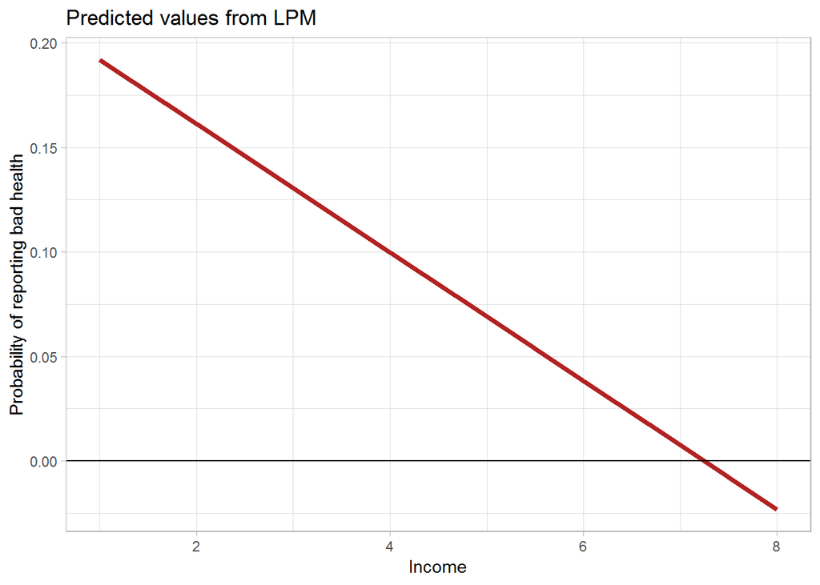

### Limited dependent variable models

In response to these concerns, researchers sometimes use a *generalized linear model*, or GLM. The most commonly applied GLMs are a logit model and a probit model. In addition, there are other types of models (Poisson, Tobit, etc.) for dealing with other types of dependent variables. Logit and probit models get around the issues with the LPM described above. Moreover, they are easy to implement in any statistical package. The primary problem with these models is that their interpretation is more difficult than an LPM.

In a probit or logit model, we (actually, R) impose a non-linear transformation that ensures that probabilities predicted from the model always fall on a scale of 0 to 1, and increase in a non-linear fashion over the range of X’s. We do this using a *link function*, which translates the linear model $\beta_0 + \beta_1\times X$ into a non-linear output on the 0-1 range. The logit and probit terms relate to the type of link function used. The logit link function is $\frac{exp(z)}{1+exp(z)}$, where $z$ is replaced by the normal right hand side of our linear regression. So the regression would be $y=\frac{exp(z)}{1+exp(z)}$ where $z=\beta_0+\beta_1 \times x_1 + \beta_2 \times x_2 + ...$. The probit function is based on the normal distribution (and we won’t get into the math). Fortunately, R has a nice easy way to implement this:

```r
# The logit model
m2 <- glm(badhealth ~ income, data=dat, family=binomial(link="logit"))
# The probit model
m3 <- glm(badhealth ~ income, data=dat, family=binomial(link="probit"))
```

Let’s see what each of these three models predict for the probability of bad health over income. Let’s once again use a 1-8 income range for these predictions, just to see how the models hold up.

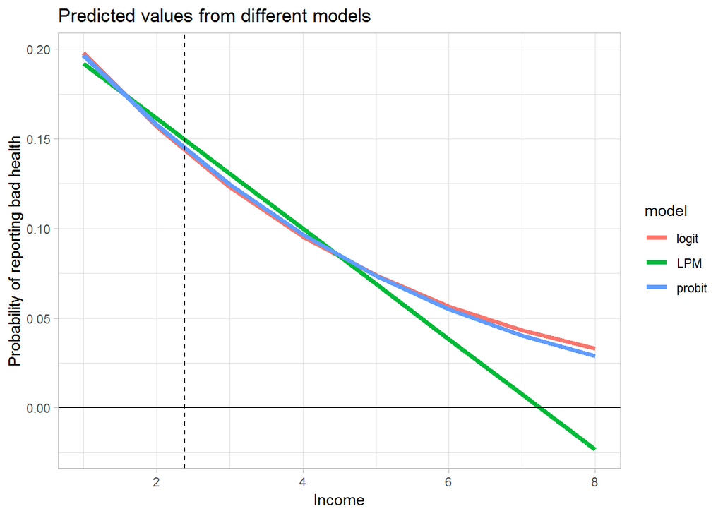

```r
newdat <- tibble(income = c(1:8))
newdat$LPM <- predict(m1, newdat)
newdat$logit <- predict(m2, newdat, type="response")
newdat$probit <- predict(m3, newdat, type="response")

newdat <- newdat %>%
  gather(key=model, value=prediction, -1)

ggplot(newdat, aes(x=income, y=prediction, colour=model)) +
  geom_line(size=1.5) +
  theme_light() +
  labs(title="Predicted values from different models",
       x="Income",
       y="Probability of reporting bad health") +
  geom_hline(yintercept = 0, colour="black") +
  geom_vline(xintercept = mean(dat$income), linetype="dashed", colour="black")
```

Let’s now look at the output of the regression.

```r
huxreg("LPM"=m1, "Logit"=m2, "Probit"=m3 )
```

|  | LPM | Logit | Probit |
| --- | --- | --- | --- |
| (Intercept) | 0.223 *** | -1.115 *** | -0.705 *** |
|  | (0.005) | (0.040) | (0.022) |
| income | -0.031 *** | -0.283 *** | -0.149 *** |
|  | (0.002) | (0.017) | (0.009) |
| N | 19538 | 19538 | 19538 |
| R2 | 0.014 |  |  |
| logLik | -7433.947 | -8086.507 | -8088.219 |
| AIC | 14873.894 | 16177.015 | 16180.439 |
| *** p < 0.001; ** p < 0.01; * p < 0.05. |  |  |  |

The LPM is straightforward to interpret, as we did above. For a one-unit increase in $X$, the average value of $Y$ decreases by 0.031 (or the probability of bad health declines by 3.1% as income increases by one category). But how to interpret the coefficients? First, note from the figure that a one-unit increase in income does not have a constant effect on health. At low income, a one unit increase seems to matter more than at high income. So we can’t just summarise the marginal effect of a change in the coefficient as simply as in the linear case, where (by definition) the effect of income on health is the same no matter what the value of income is. We can calculate *marginal effects* from these models. Marginal effects relate, link in the linear regression, to the slope of the line in the figure above. Since the slopes for the logit and probit models change with income, we have to pick some value of income to look at. Mean income is given by the dashed vertical line in the figure above. We will calculate the change in health with income, assuming income is at the mean income level. These calculations are based on the link functions.

```r
# Marginal effects
# Logit
logit_intercept <- as.numeric(coef(m2)[1])
logit_coef <- as.numeric(coef(m2)[2])
mean_x <- mean(dat$income)
z_1 <- logit_intercept + logit_coef * (mean_x + 1)
z_0 <- logit_intercept + logit_coef * (mean_x)

print("Logit model: Effect of a one-unit change in income on health at mean income: ")
```

```
## [1] "Logit model: Effect of a one-unit change in income on health at mean income: "
```

```r
exp(z_1) / (1+exp(z_1)) - exp(z_0)/(1+exp(z_0))
```

```
## [1] -0.03134577
```

```r
# Same as LPM

# Probit
probit_intercept <- as.numeric(coef(m3)[1])
probit_coef <- as.numeric(coef(m3)[2])
mean_x <- mean(dat$income)
z_1 <- probit_intercept + probit_coef * (mean_x + 1)
z_0 <- probit_intercept + probit_coef * (mean_x)

print("Probit model: Effect of a one-unit change in income on health at mean income: ")
```

```
## [1] "Probit model: Effect of a one-unit change in income on health at mean income: "
```

```r
pnorm(z_1) - pnorm(z_0)
```

```
## [1] -0.0312186
```

```r
# Same as LPM
```

You can see that the *marginal effects* for both the logit and probit model are identical to the LPM (a 3.1 percent reduction in probability of bad health for a one-unit change in income, at mean income levels). You can see this in the figure above: the slopes of all three models are pretty much exactly the same, at the mean income level. At other income levels, the slopes diverge.

Fortunately, we don’t necessairily need to do these calculations, because there is (another) R package that will do them for us: the `margins` package. You can install this using `install.packages("margins")`. Then we can get the slope of each line (the marginal effect of a change in x on y) using `margins`. For example, to find the marginal effect of a change in $X$ on $Y$ for the logit model, use `margins(m2)`. The result is very slightly different than the result calculated above, for reasons that are described [here](https://cran.r-project.org/web/packages/margins/vignettes/Introduction.html).